# CCS d1 与 Direct-GSClassifier 消融实验

Bensz Conan

2026-08-29

本报告关注两个相互衔接的问题：冻结 cohort bank 将 529 维 GSClassifier 原生输入重编码为 d1 后，技术边界、lineage recoverability 和输入重建如何变化；继续增加 cohort evidence 时，非冗余信息与邻域稳定性究竟来自 tissue breadth，还是来自既有 tissue 内的 cohort depth。主 scaling 合同使用 529 维完整 Direct-GSClassifier，496 维 Direct-GSClassifier-TSP 仅作为明确标记的 gene-pair 敏感性诊断。

可以把 Direct-GSClassifier 想成一本保存原始线索的详细笔记，把 d1 想成 150 位“队列评委”读完笔记后分别给出的判断。我们不是先问哪本笔记分数更高，而是依次确认：新笔记是否真的换了一种组织信息的方式、是否减弱了不希望保留的技术来源痕迹、压缩时丢掉了什么，以及增加更多评委时得到的是新意见还是重复意见。

**核心结论的判据不再由癌种分类单独承担。** 总体结果显示，d1 一方面重新组织了 Direct 的样本几何并弱化旧癌种标签的可恢复性，另一方面降低了同技术来源样本的额外聚集；继续增加 cohort evidence 时，信息方向、module 重复性和邻域稳定性也并非同步改善。后文会在每个指标第一次进入结果解读时说明“是什么、怎么算、数值怎样读”，再结合本次动态结果给出判断。由于独立 pathway、TME 或 outcome 锚点当前为 **not_evaluated**，这些结果可以约束非冗余信息、技术边界和组成稳定性，却不能把 cancer type 替代为 CCS 新状态效用的证据。

## 1 数据概览

### 1.1 实验数据与表示定义

原始 filtered 集合包含 43 个 cohort。其中，36 个 cohort 的 cancer_type 在 reference 中至少覆盖 2 个 cohort，共得到 10103 个确认性 query。reference atlas 包含 24487 个可唯一对齐的样本，来自 147 个 cohort。所有 query 的 d1 provenance 均为 `external_frozen`；独立锚点取自 Excel 证据层中的 cancer_type，本轮证据等级为 **confirmatory**。Direct-GSClassifier 使用 529 个真实冻结特征，其中包含 496 个 ordinary gene-pair；Cohort-d1 则由 150 个冻结 module 产生 583 个概率输出列。

在画图和比较分数之前，先把样本、cohort、特征和 module 的数量摊开，是为了确认两种表示面对的是同一批题目，而不是一边题目简单、另一边题目困难。下面的表像实验的“装箱清单”：reference 是可供查找的答案库，query 是从未进入该答案库的新题，feature 是原始线索，module 是不同队列模型给出的证据单元。计数本身不判胜负，它们的价值是让任何性能差异都能追溯到明确且公平的比较对象。

```r
# Purpose: Expose the exact data and representation contract used by all analyses.
# Input: manifest.rds.
# Parameters: Eleven visible rows; horizontal scrolling retained for audit fields.
# Output: Interactive data overview table.
overview_table <- data.frame(
  item = c(
    "Evidence level",
    "Reference samples",
    "External query samples",
    "Reference cohorts",
    "External filtered cohorts",
    "Direct features",
    "Gene signature size",
    "Ordinary gene-pairs",
    "d1 modules",
    "d1 output columns",
    "Direct / d1 distance"
  ),
  value = c(
    manifest$evidence_level,
    manifest$reference_sample_count,
    manifest$query_sample_count,
    manifest$reference_cohort_count,
    manifest$query_cohort_count,
    manifest$direct_feature_count,
    manifest$gene_signature_count,
    manifest$tsp_feature_count,
    manifest$module_count,
    manifest$d1_feature_count,
    paste(manifest$direct_distance, manifest$d1_distance, sep = " / ")
  ),
  stringsAsFactors = FALSE
)
render_dt(overview_table, pageLength = 11)
```

|  | item | value |
| --- | --- | --- |
| 1 | Evidence level | confirmatory |
| 2 | Reference samples | 24487 |
| 3 | External query samples | 10103 |
| 4 | Reference cohorts | 147 |
| 5 | External filtered cohorts | 36 |
| 6 | Direct features | 529 |
| 7 | Gene signature size | 32 |
| 8 | Ordinary gene-pairs | 496 |
| 9 | d1 modules | 150 |
| 10 | d1 output columns | 583 |

[output cut: 1 more lines]

这些计数界定了本次比较的对象：同一批表达样本在两种表示下的结果。主消融和 scaling 的主 Direct 合同都使用完整 529 维 GSClassifier 输入；496 个 ordinary gene-pair 只作为 `Direct-GSClassifier-TSP` 敏感性合同。另有 271 个跨 cohort 重复的 sample ID 被整体排除，避免同名样本在 reference/query 对齐时被误当作配对。完整的数据构成、tissue 恢复结果和来源异质性见第一阶段报告 01-ablation-test-data.html。

## 2 关键函数、参数与源代码位置

这一表不是为了让客户阅读代码，而是说明每个结论由哪台“测量仪器”产生、旋钮设在哪里、为什么这样设。若某项结果令人意外，客户可以沿着对象、参数和源文件回查，而不必把整份报告当成无法拆开的黑箱；这也是区分“数据真的这样”与“参数选择造成这样”的必要步骤。

| 分析过程/产物 | 关键函数/对象 | 关键参数 | 本次设置理由 | 源代码位置 |
| --- | --- | --- | --- | --- |
| 数据审计输入 | `data_profile` | tmp/ablation-experiment/data-profile.rds | 复用第一阶段完整画像，不在实验报告中重复加载或重画数据审计 | 01-ablation-test-data.Rmd |
| 完整 GSClassifier 输入 | `.ablation_gsclassifier_matrix()` | 冻结 `geneSet`、`breakVec`、feature manifest | 保留 32 single-bin、496 gene-pair、1 set-pair 的真实合同 | `R/ablation.R:` 1132 |
| 外部 d1 重编码 | `.ablation_encode_d1_from_direct()` | 150 modules；模型 repeat 中位数 | filtered query 从未参与 bank 训练；优化编码与既有 d1 零误差一致 | `R/ablation.R:` 3833 |
| query-to-reference 检索 | `.ablation_query_reference_retrieval()` + `.ae_retrieval_inference()` | k = 5/15/30；cohort bootstrap = 2000 | query 只到其它 cohorts 的 atlas 找邻居；按 cohort 估计 CI 与配对 p 值 | `R/ablation.R:` 3964；`02-ablation-experiment_functions.R` |
| d1 距离 | `.ablation_module_balanced_transform()` | module 等权标准化 Euclidean | d1 blocks 的行和不满足 simplex，故不伪用 Hellinger | `R/ablation.R:` 3927 |
| 外部 readout | `.ablation_linear_readout()` + `.ae_readout_inference()` | grouped 3-fold CV；lambda = 0.1/1/10 | 预处理与调参均在 reference 内完成，两臂预算一致；query cohort bootstrap 单独报告 | `R/ablation.R:` 5293；`02-ablation-experiment_functions.R` |
| 配对学习曲线 | `.ablation_learning_curve()` + `.ae_learning_inference()` | 10/25/50/100% × 3 repeats | 区分小样本归纳偏置与信息上限；以 design repeat 做配对 CI | `R/ablation.R:` 5473；`02-ablation-experiment_functions.R` |
| cohort-evidence scaling | `.ablation_cohort_bank_design()` / `.ablation_representation_scaling()` | breadth、depth、matched-size × 5 repeats；完整 Direct 主合同 + TSP sensitivity | 分离 tissue breadth 与 within-tissue depth；bootstrap 只重采样 design repeat | `R/ablation.R:` 5870 |
| 信息损失 | `.ablation_decode_direct_features()` | rank = 50；ridge lambda = 1 | 按 feature type 量化 d1 无法恢复的原生输入 | `R/ablation.R:` 6884 |

## 3 指标取值与通俗解读

本表是一份便于回查的快速索引，集中列出理论范围、趋势方向和通俗含义。端点是可靠锚点，但中间值通常没有跨数据集通用的及格线；为了让第一次阅读报告的读者不必在章节之间来回跳转，后文会在每个指标第一次进入结果解读时再次说明计算方法，并立即结合本次数字解释。

| 指标 | 取值范围 | 意义（包括趋势变化） | 通俗解读 |
| --- | --- | --- | --- |
| Annoy neighbor recall | 零至一（含端点） | 越接近一，近似检索找回的 exact kNN 邻居越完整；下降到门槛以下时，后续邻域差异可能来自搜索误差 | 像快速翻通讯录找朋友：一表示一个都没漏，越低表示漏掉的人越多 |
| Linear CKA | 零至一（含端点） | 升高表示两种表示的整体几何更相似；降低表示全局结构被改写得更多，但不直接代表好坏 | 像比较两张班级座位图：越接近一，整张图越像 |
| Distance Spearman | 负一至一（含端点） | 升高表示样本远近排序更一致；接近零表示缺少稳定排序关系，负值表示顺序趋向反转 | 像比较两份“从近到远”名单：一表示顺序完全一样，负值像把顺序倒过来 |
| kNN Jaccard | 零至一（含端点） | 升高表示两种表示共享更多局部邻居；降低表示“谁挨着谁”被重新排列 | 像比较两张好友名单：一表示好友完全相同，零表示一个都不一样 |
| Neighbor stability | 零至一（含端点） | 升高表示更换 bank 组成后邻居关系仍稳定；降低表示结果更依赖某次抽样 | 像每次重新排队后，好朋友是否还站在一起；越高越稳定 |
| top-k 癌种一致率 | 零至一（含端点） | 升高表示前 k 个邻居更常与 query 同癌种，旧癌种边界更强；降低表示去癌种中心化增强 | 像看最相近的 k 位同学里有多少来自同一个班，越多分数越高 |
| MRR | 零至一（含端点） | 升高表示首个同癌种邻居出现得更靠前；降低表示需要向后找更久 | 像排队找第一个同班同学：排第一得满分，排得越后分越低，找不到记零 |
| Balanced accuracy | 零至一（含端点）；随机基线随类别数变化 | 升高表示各类别被更公平地识别；降低表示至少部分小类别更难识别，不能把多分类任务机械套用二分类基线 | 像每个班都有同样的一票，大班不能靠人数多把小班淹没 |
| Macro-AUROC | 零至一（含端点）；二分之一约为随机排序 | 升高表示各癌种更容易排在正确一侧；接近二分之一表示接近随机，低于二分之一表示排序方向可能反了 | 像把同班和不同班同学排成两队：越接近一，排得越整齐 |
| Normalized effective rank | 大于零且不超过一；下界随最大秩变化 | 升高表示非重复的信息方向占可用容量的比例增大；降低表示信息相对更集中在少数方向 | 像一盒彩笔里真正不同的颜色比例：颜色越多，能画出的内容越丰富 |
| Module redundancy | 零至一（含端点） | 升高表示 modules 之间更像重复信息；降低表示每个 module 提供的独立信息更多 | 像很多人重复同一句话：越接近一，重复越多 |
| Scaling slope | 没有统一固定范围；零表示平均不变 | 正值表示每增加一单位 evidence 指标上升，负值表示下降；绝对值表示每单位变化量，breadth 与 depth 单位不同不能直接比大小 | 像每上一级台阶升高或降低多少；台阶单位不同，不能只看数字判输赢 |
| d1−Direct 配对差 | 对零至一指标而言为负一至一 | 零表示不变；正值表示 d1 更高，负值表示 d1 更低；差十分之一等于绝对改变十个百分点 | 像两次考试分数相减：正数表示第二次更高，负数表示第二次更低 |
| breadth-heavy−depth-heavy 配对差 | 负一至一（含端点） | 零表示相同 module 总数下两种分配无差异；effective rank/stability 正值偏向 breadth，redundancy 负值偏向 breadth | 像给两队同样多的座位，再看“多去不同年级”和“同年级多听几个班”哪种安排更合适 |
| Technical-neighbor excess 差 | 单臂 excess 为负一至一；d1−Direct 为负二至二 | 负值表示 d1 减少额外同技术邻居聚集，正值表示聚集增强；负十分之一表示减少十个百分点 | 像先扣除“本来就同班”的影响，再看同款相机拍的照片是否仍爱挤在一起 |
| Module variance share | 零至一（含端点），所有 modules 之和为一 | 单个或 Top 组占比升高表示贡献更集中在少数 modules；下降表示更多 modules 共同参与 | 像把所有人的音量合成一百分，再看哪几个人说话最响 |
| Brier score | 零至一（含端点） | 越低表示概率预测越准；上升表示预测概率离正确答案更远；图中用“一减 Brier”后方向改为越高越好 | 像猜下雨概率：不仅看猜对没猜对，还看你有多确定，离答案越远扣分越多 |
| Spearman | 负一至一（含端点） | 升高表示重建后高低排序保留得更好；接近零表示排序不稳定，负值表示排序趋向反转 | 像把玩具按高矮重新排队：越接近一，重排后的顺序越像原来 |
| MAE / RMSE | 零至正无穷，没有统一上限 | 越低越好；RMSE 对少数特别大的错误惩罚更重，只能在相同量纲内比较 | MAE 像平均每次差几厘米；RMSE 会对“错得特别离谱”的那几次额外扣分 |
| 图中的误差重建分数 | 对“误差加一”取倒数，大于零且不超过一 | 一表示零误差；误差增大时分数向零下降，这是展示变换而不是原始 MAE/RMSE | 像把“错误越小越好”翻成“分数越高越好”，方便把柱子朝同一方向读 |

Annoy 是用于加速近邻搜索的近似算法；exact kNN 则逐一计算距离，可视为本报告的检索参照。对每个抽查 query，neighbor recall 用“Annoy 找回的 exact 邻居数 ÷ exact 邻居总数”计算，再在抽查样本间取平均；一表示应找回的邻居一个都没有漏。Annoy 配置为 75 棵树，search budget 为 10000。与 exact kNN 对照后，Direct 和 d1 的 recall 分别为 0.979 和 0.986，均高于预设门槛 0.900。因此，后续观察到的 top-k 差异不太可能主要由近似搜索漏邻居造成。

## 4 d1 与癌种标签的判读边界

在 CCS 的 feature–cohort 融合中，新样本的 `cohort_id` 不作为输入标签；多个冻结队列模型 $F_m$ 分别从各自的队列视角读取同一份样本特征 $X$：

$$d1(X)=\{F_1(X),F_2(X),\ldots,F_M(X)\}.$$

用更直观的话说，同一个新样本像拿着同一幅画去问多位老师，每位老师只依据自己过去教过的 cohort 给出一个判断；d1 保存的是这一排判断，而不是把新样本硬塞回某个已知 cohort。这个设计的价值在于汇总不同队列视角，同时也意味着某位老师共同拥有的偏见可能被带入结果，所以后面既要检查新空间，也要检查技术来源和信息损失。

d1 同时编码样本内的 feature pattern 和固化在模型参数中的 cohort-derived prior，因此更适合被理解为“多个队列对新样本给出的证据向量”，而不是 Direct-GSClassifier 的无损副本。这种设计使新状态有可能跨越传统癌种边界，也为少量可部署 feature 如何随队列证据增加而扩展提供了解释。该概念与项目内的 CCS 方法学讨论，以及论文中“low-input features + cohort consensus + transferable states”的表述一致。

| 本报告的观察 | 能支持的判断 | 不能支持的判断 |
| --- | --- | --- |
| 癌种 top-k 与线性 readout 下降 | d1 弱化了旧癌种标签的可恢复性 | d1 没有新分型价值 |
| assay/platform/source excess 下降 | d1 减少了超出癌种构成可解释范围的技术来源聚集 | batch removal 已经成功，或所有生物结构都被保留 |
| Direct feature 不能完全重建 | d1 实施了有损、有方向的压缩 | 丢失的一定是下游任务所需信息 |
| 本轮未测 d2/d3/metaCCS/outcome | 现有证据只能约束 d1 与 cohort-bank scaling 的机制解读 | CCS 新状态发现或临床分层已胜出/失败 |

癌种结构仍应作为一项保护性参照。当前 CCS 论文认为，lineage-restricted states 与 broadly shared states 可以并存，下游机制也可能表现出 lineage-dependent realization。癌种可恢复性下降或许反映了预期中的“去癌种中心化”，但不能单独用来判定方法成功。要让这一解释成立，还需要证明新状态在未见 cohort 中保持稳定，携带跨癌种共享的生物信号，并保留可复现的 lineage-conditioned 差异。

## 5 d1 对原生空间的改写

先比较空间几何，是因为 d1 若与 Direct 几乎完全相同，就没有形成新的表示；若结构被彻底打乱，也可能只是破坏信息。本节把 Direct 和 d1 写成两张矩阵 $X$ 与 $Y$：每一行是同一个样本，每一列是该表示中的一个特征。两张矩阵列数可以不同，但样本必须一一对应。本次几何指标使用分层抽取的 5000 个 reference 样本；Direct 按 reference 均值和标准差进行标准化，d1 也在 reference 边界内标准化，并让每个 module 对欧氏距离贡献等权。局部邻居使用 $k=$ 30，Distance Spearman 最多抽取 100000 个有序样本对进行估计。

Linear CKA 先对各列减去均值，再比较两张“样本两两关系表” $K=X_cX_c^\top$ 和 $L=Y_cY_c^\top$：

$$\operatorname{CKA}(X,Y)=
\frac{\lVert X_c^\top Y_c\rVert_F\,\lVert X_c^\top Y_c\rVert_F}
{\lVert X_c^\top X_c\rVert_F\,\lVert Y_c^\top Y_c\rVert_F}.$$

这个式子等价于两张关系表的余弦相似度：接近一表示整张样本地图方向一致，接近零表示缺少整体线性对应；它不是“保留信息的百分比”。Distance Spearman 则随机抽取样本对，分别计算它们在 Direct 和 d1 中的欧氏距离，再比较两份距离的名次；一表示被抽取样本对的远近次序完全一致，零表示没有稳定的名次关系。kNN Jaccard 更关注局部：对每个样本分别取得两种表示下的 $k$ 个最近邻，用“共同邻居数 ÷ 两份名单的并集数”计算，最后对样本取平均；一表示邻居名单完全相同，零表示没有共同邻居。三者分别对应“整张地图”“抽样远近排序”和“身边是谁”。

```r
# ==== Figure 1: Native geometry agreement (user-adjustable parameters) ====
fig1 <- list(
  # Canvas size in inches. Wider canvases leave room for metric labels.
  width_in = 6.2,
  height_in = 3.8,
  # Base font in pt. Values below 8 are avoided for print readability.
  base_size = 11,
  # Bar width and legend position; no in-panel title is used.
  bar_width = 0.68,
  legend_position = "none"
)

p1 <- ggplot2::ggplot(
  geometry_metrics,
  ggplot2::aes(x = .data$metric_label, y = .data$metric_value)
) +
  ggplot2::geom_col(
    width = fig1$bar_width,
    fill = nature_colors[["blue"]]
  ) +
  ggplot2::geom_text(
    ggplot2::aes(label = sprintf("%.3f", .data$metric_value)),
    vjust = -0.45,
    size = 3.6
  ) +
  ggplot2::geom_text(
    ggplot2::aes(label = "CI / p: not estimable"),
    vjust = 1.8,
    size = 2.7,
    color = "grey35"
  ) +
  ggplot2::scale_y_continuous(
    limits = c(0, 1.05),
    breaks = seq(0, 1, 0.2),
    expand = ggplot2::expansion(mult = c(0, 0.02))
  ) +
  ggplot2::labs(x = NULL, y = "Agreement") +
  theme_nature_readable(
    base_size = fig1$base_size,
    x_text_angle = 0,
    legend_position = fig1$legend_position
  )

# Readability check: three short labels fit without rotation; values are printed
# above bars, and the y margin prevents clipping in PDF/JPG rendering.
fig1_jpg <- .ae_save_plot(
  p1, "figure-01-native-geometry", figure_dir, preview_dir, fig1,
  params$plot_preview_dpi
)
```

```
## Converting page 1 to E:/RCloud/RFactory/ccs/test/ablation-02/tmp/plot-previews/02-ablation-experiment-20260829223955/figure-01-native-geometry.jpg... done!
```

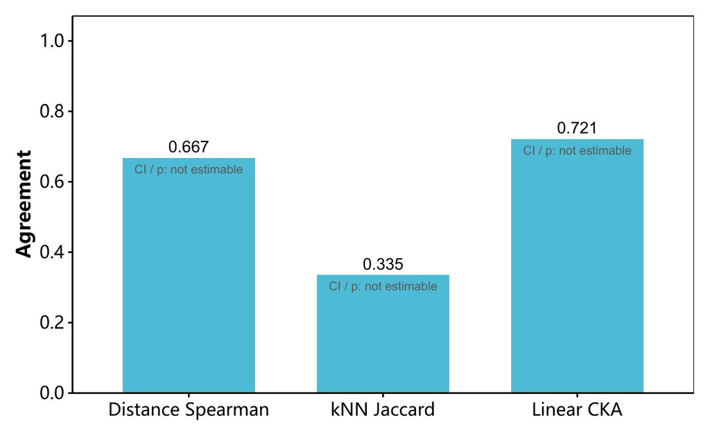

```r
knitr::include_graphics(fig1_jpg)
```

Figure 1 显示三个几何指标来自一次冻结 reference 几何计算；当前 RDS 未保存可按 cohort 重抽取的样本级矩阵或独立 geometry repeats，因此不能把单次 CKA、Distance Spearman 或 kNN Jaccard 的差异人为扩展成置信区间。这里将它们明确标记为 `not_estimable`，而不是用样本数当作独立重复。后续若保存每个 cohort 的几何矩阵或重复计算结果，再补充真正的 geometry-level CI。

```r
geometry_inference_table <- geometry_inference[, c(
  "endpoint", "estimate", "ci_low", "ci_high", "p_value", "n_sample",
  "unit", "method", "status", "reason"
)]
render_dt(geometry_inference_table, pageLength = 3L)
```

|  | endpoint | estimate | ci_low | ci_high | p_value | n_sample | unit | method | status | reason |
| --- | --- | --- | --- | --- | --- | --- | --- | --- | --- | --- |
| 1 | linear_cka | 0.7211347227060824 |  |  |  | 5000 | not_available | not_estimable_single_frozen_geometry | not_estimable | native_geometry_contains_one_frozen_estimate |
| 2 | distance_spearman | 0.6669794284963206 |  |  |  | 5000 | not_available | not_estimable_single_frozen_geometry | not_estimable | native_geometry_contains_one_frozen_estimate |
| 3 | knn_jaccard | 0.334874872482664 |  |  |  | 5000 | not_available | not_estimable_single_frozen_geometry | not_estimable | native_geometry_contains_one_frozen_estimate |

本次几何结果的直接解读是：CKA = 0.721，说明 d1 与 Direct 的整体样本关系仍有较强一致性，但不是简单复制；Distance Spearman = 0.667，表示大尺度的远近排序仍保持清楚的正向关系。kNN Jaccard = 0.335，即共同邻居约占两份邻居名单并集的 33.5%。由于两份名单都含相同数量的邻居，这一 Jaccard 值粗略对应每份名单约 50.2% 的成员相同；这是便于理解的换算，不能代替逐样本分布。

CKA 与 Distance Spearman 共同表明全局关系和抽样远近排序仍有明显保留，而 kNN Jaccard 单独表明局部“谁紧挨着谁”发生了更大重排。**这三项指标的定义和标尺不同，不能因为 CKA 的数字大于 Jaccard，就把两者当作同一把尺子直接比较。** 形成新的证据空间是 CCS 实现新分型的必要条件，但三者都只描述“改了多少、改在什么尺度”，不能判断改写是否有益。还需结合技术边界是否减弱、新状态是否稳定、跨癌种生物锚点是否共享以及实际任务效用来评估。

## 6 外部癌种标签检索

这一步把未参与 reference atlas 构建的 query 放进地图，并且只允许它到其他 cohorts 的 reference 样本中找邻居，避免同一队列的技术或来源特征直接制造“近邻”。对 query $q$，top-k 癌种一致率计算为

$$\operatorname{TopKRate}_q=
\frac{\sum_{j\in\mathcal{N}_k(q)}I(c_j=c_q)}{|\mathcal{N}_k(q)|},$$

也就是前 $k$ 个邻居中与 query 同癌种的比例。MRR 是 mean reciprocal rank：若第一个同癌种邻居排在第 $r_q$ 名，则该样本得分为 $1/r_q$，最后对所有 query 取平均；排第一得一分，排第二得二分之一，越靠后分数越小。当前实现只在最多 30 名邻居内寻找首次命中，未找到记零，因此本报告中的 MRR 应理解为截断到前 30 名的 MRR。本次展示参数也是 30，两者恰好一致；若以后只修改展示用 $k$，不能自动把 MRR 解释成新的 `MRR@k`。

图中展示的是每个样本的“d1 减 Direct”配对差，再在 cohort 内取平均。差值为正表示 d1 更容易恢复旧癌种标签，负值表示 d1 的邻域更少由旧癌种主导；它衡量的是 lineage recoverability，不是 CCS 新状态的正确率。虚线是所有 query 的样本级平均，因此样本多的 cohort 权重更大；散点则是各 cohort 内的样本均值，用于识别异质性。Top-k 与 MRR 的绝对值没有减去“该癌种在合格 reference 中所占比例”的机会基线，不同癌种不能只凭绝对分数横向判优；本报告主要依靠同一 query、同一 reference 候选池下的 d1−Direct 配对差保证比较口径一致。

### 6.1 检索差异的 cohort-level 推断

下面的推断以 query cohort 为统计单位。每次 bootstrap 对完整 cohort 有放回抽取，并在同一索引下保留 Direct/d1 配对；sign-flip 检验的零假设是平均配对差为零。`n_sample` 仅用于描述数据量，不被当成独立重复数。

```r
retrieval_inference_table <- retrieval_inference[, c(
  "endpoint", "estimate", "ci_low", "ci_high", "p_value", "p_value_adj",
  "n_cohort", "n_sample", "resamples", "unit", "multiplicity_method", "status"
)]
render_dt(retrieval_inference_table, pageLength = 3L)
```

|  | endpoint | estimate | ci_low | ci_high | p_value | p_value_adj | n_cohort | n_sample | resamples | unit | multiplicity_method | status |
| --- | --- | --- | --- | --- | --- | --- | --- | --- | --- | --- | --- | --- |
| 1 | top_k_label_rate | -0.06034628458981168 | -0.08975629817985942 | -0.03038129899059372 | 0.0009995002498750624 | 0.002998500749625187 | 36 | 10103 | 2000 | cohort | holm | complete |
| 2 | mrr | -0.04789050732209673 | -0.07847728249374995 | -0.01633745689241052 | 0.004497751124437781 | 0.008995502248875561 | 36 | 10103 | 2000 | cohort | holm | complete |
| 3 | top1_label_match | -0.05563198976387065 | -0.09132545763211743 | -0.02212480888741072 | 0.004997501249375313 | 0.008995502248875561 | 36 | 10103 | 2000 | cohort | holm | complete |

结论：该表给出的效应量、区间和配对检验共同描述了 cohort 重采样下的检索差异稳定性。

#### 6.1.1 检索推断结果解读

在预先指定的 `k =` 30 主要终点上，top-k 配对差估计为 -0.060，95% CI 为 [-0.090, -0.030]，双侧 p = <0.001（Holm 校正后 0.003）。这个区间描述 cohort 重采样下效应量的可变范围，不能替代生物学效用终点；若区间跨零或 p 值未达到 0.05，应表述为证据不足以拒绝零差异，而不是“没有差异”。MRR 与 top1 是次要终点，校正后的结果需结合其有效 cohort 数、方向和区间共同判读。

```r
# ==== Figure 2: External retrieval cohort deltas (user-adjustable parameters) ====
fig2 <- list(
  # Larger height protects cohort labels from overlap; adjust with cohort count.
  width_in = 8.0,
  height_in = 8.5,
  base_size = 9,
  point_size = 2.2,
  zero_line_width = 0.55,
  legend_position = "bottom"
)
plot_retrieval <- retrieval_cohort_delta[
  retrieval_cohort_delta$sample_count >= params$min_cohort_n &
    retrieval_cohort_delta$metric %in%
      c("delta_top_k_label_rate", "delta_mrr"),
  ,
  drop = FALSE
]
plot_retrieval$metric <- factor(
  plot_retrieval$metric,
  levels = c("delta_top_k_label_rate", "delta_mrr"),
  labels = c("Top-k label rate", "Mean reciprocal rank")
)
retrieval_overall_plot <- data.frame(
  cohort = "Overall",
  metric = factor(
    c("Top-k label rate", "Mean reciprocal rank"),
    levels = levels(plot_retrieval$metric)
  ),
  estimate = c(retrieval_mean_delta, retrieval_mrr_delta),
  ci_low = c(
    retrieval_inference$ci_low[retrieval_inference$endpoint == "top_k_label_rate"],
    retrieval_inference$ci_low[retrieval_inference$endpoint == "mrr"]
  ),
  ci_high = c(
    retrieval_inference$ci_high[retrieval_inference$endpoint == "top_k_label_rate"],
    retrieval_inference$ci_high[retrieval_inference$endpoint == "mrr"]
  ),
  sample_count = NA_integer_,
  stringsAsFactors = FALSE
)
plot_retrieval$ci_low <- NA_real_
plot_retrieval$ci_high <- NA_real_
retrieval_overall_plot <- retrieval_overall_plot[, names(plot_retrieval), drop = FALSE]
plot_retrieval <- rbind(plot_retrieval, retrieval_overall_plot)
retrieval_reference <- data.frame(
  metric = factor(
    c("Top-k label rate", "Mean reciprocal rank"),
    levels = levels(plot_retrieval$metric)
  ),
  estimate = c(retrieval_mean_delta, retrieval_mrr_delta),
  ci_low = c(
    retrieval_inference$ci_low[retrieval_inference$endpoint == "top_k_label_rate"],
    retrieval_inference$ci_low[retrieval_inference$endpoint == "mrr"]
  ),
  ci_high = c(
    retrieval_inference$ci_high[retrieval_inference$endpoint == "top_k_label_rate"],
    retrieval_inference$ci_high[retrieval_inference$endpoint == "mrr"]
  )
)
cohort_order <- retrieval_delta_main$cohort[
  order(retrieval_delta_main$estimate)
]
plot_retrieval$cohort <- factor(plot_retrieval$cohort, levels = c(cohort_order, "Overall"))

p2 <- ggplot2::ggplot(
  plot_retrieval,
  ggplot2::aes(x = .data$estimate, y = .data$cohort, color = .data$metric)
) +
  ggplot2::geom_vline(
    xintercept = 0,
    linewidth = fig2$zero_line_width,
    color = "grey55"
  ) +
  ggplot2::geom_vline(
    data = retrieval_reference,
    ggplot2::aes(xintercept = .data$estimate, color = .data$metric),
    inherit.aes = FALSE,
    linetype = "dashed",
    linewidth = fig2$zero_line_width,
    show.legend = FALSE
  ) +
  ggplot2::geom_errorbar(
    data = plot_retrieval[plot_retrieval$cohort == "Overall", , drop = FALSE],
    ggplot2::aes(xmin = .data$ci_low, xmax = .data$ci_high),
    orientation = "y",
    width = 0.22,
    linewidth = fig2$zero_line_width,
    position = ggplot2::position_dodge(width = 0.45),
    show.legend = FALSE,
    na.rm = TRUE
  ) +
  ggplot2::geom_point(size = fig2$point_size) +
  ggplot2::scale_color_manual(
    values = c(
      "Top-k label rate" = nature_colors[["red"]],
      "Mean reciprocal rank" = nature_colors[["blue"]]
    )
  ) +
  ggplot2::labs(
    x = "Cohort-d1 minus Direct-GSClassifier",
    y = "External query cohort",
    color = "Metric",
    caption = paste0(
      "Dashed lines: sample-level means; overall cohort-bootstrap 95% CI [",
      paste(fmt(retrieval_reference$ci_low), fmt(retrieval_reference$ci_high), collapse = "; "),
      "]; p(top-k) = ", fmt_p(retrieval_inference$p_value[retrieval_inference$endpoint == "top_k_label_rate"]),
      "; p(MRR) = ", fmt_p(retrieval_inference$p_value[retrieval_inference$endpoint == "mrr"])
    )
  ) +
  theme_nature_readable(
    base_size = fig2$base_size,
    x_text_angle = 0,
    legend_position = fig2$legend_position
  )

# Readability check: cohort labels use a tall canvas, the zero line makes gain/loss
# direction explicit, and the bottom legend does not cover data.
fig2_jpg <- .ae_save_plot(
  p2, "figure-02-external-retrieval-cohort-delta", figure_dir,
  preview_dir, fig2, params$plot_preview_dpi
)
```

```
## Converting page 1 to E:/RCloud/RFactory/ccs/test/ablation-02/tmp/plot-previews/02-ablation-experiment-20260829223955/figure-02-external-retrieval-cohort-delta.jpg... done!
```

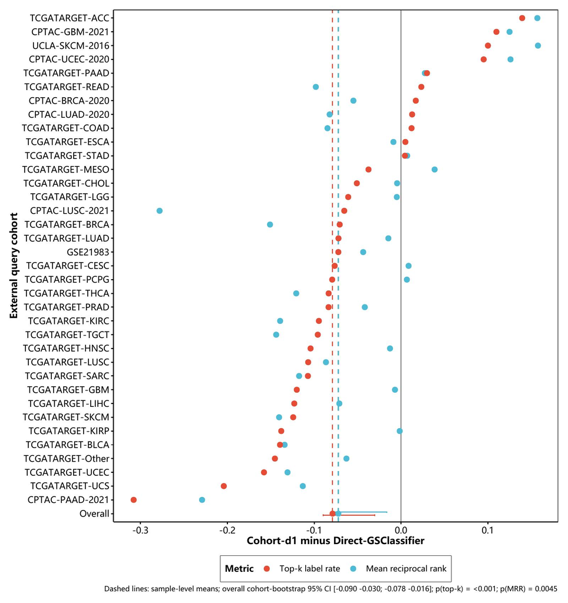

```r
knitr::include_graphics(fig2_jpg)
```

本次检索结果的直接解读是：在 $k=$ 30 时，top-k 癌种一致率从 Direct 的 0.437 降至 d1 的 0.358，相当于前 30 个邻居中同癌种者平均从约 13.1 个降至 10.7 个；样本级配对平均差为 **-0.079**，即下降 7.9 个百分点。MRR 同时从 0.624 降至 0.552，配对平均差为 -0.072，说明第一个同癌种邻居总体出现得更靠后；由于倒数排名是非线性分数，这个差值不能直接翻译成“后移几名”。

两项指标同向下降，表明传统癌种标签对 d1 局部几何的主导作用较弱，但不能由此直接推断其生物学效用下降。正向差值最大的三个 cohort 依次为 TCGATARGET-ACC、CPTAC-GBM-2021 和 UCLA-SKCM-2016；癌种可恢复性下降幅度最大的是 **CPTAC-PAAD-2021**（-0.308）。**cohort 之间并不一致，说明 cohort bank 对 lineage 信号的重加权具有明显异质性。** 在据此收缩 d1 的适用范围之前，还需确认这些 cohort 是否对应可复现的共享状态。

```r
# Purpose: Expose the strongest external retrieval gains and losses with sample counts.
# Input: Cohort-level paired top-k cancer-type agreement deltas.
# Parameters: Top/bottom count from params$interpret_top_n.
# Output: Interactive table of concrete cohorts and effect directions.
retrieval_extremes <- rbind(
  transform(utils::head(retrieval_top, params$interpret_top_n), direction = "gain"),
  transform(utils::head(retrieval_bottom, params$interpret_top_n), direction = "loss")
)
render_dt(
  retrieval_extremes[, c("direction", "cohort", "estimate", "sample_count")],
  pageLength = 2L * params$interpret_top_n
)
```

|  | direction | cohort | estimate | sample_count |
| --- | --- | --- | --- | --- |
| 1 | gain | TCGATARGET-ACC | 0.1393939393939394 | 77 |
| 2 | gain | CPTAC-GBM-2021 | 0.1097643097643098 | 99 |
| 3 | gain | UCLA-SKCM-2016 | 0.1 | 27 |
| 4 | loss | CPTAC-PAAD-2021 | -0.3078571428571429 | 140 |
| 5 | loss | TCGATARGET-UCS | -0.204093567251462 | 57 |
| 6 | loss | TCGATARGET-UCEC | -0.1578268876611418 | 181 |

#### 6.1.2 检索极端 cohort 解读

结论：极端 cohort 的方向差异是该表最重要的观察结果，应结合有效样本量与后续分层分析解释。

该表进一步展示了 lineage 重加权在具体 query cohort 中的差异。TCGATARGET-ACC 与 CPTAC-PAAD-2021 的方向相反，说明 cohort bank 对不同癌种的重加权强度和方向并不一致。下一步可分别按 assay/source 对这两类 cohort 分层，检验 d1 邻居在 pathway score、TME state 或其他非癌种锚点上是否更加一致。若跨 cohort 的状态一致性提高，且 Annoy/exact recall 仍高于 0.900，便更支持这是“有目的的结构重构”，而不必要求癌种 top-k 差值转为正向。

## 7 外部癌种线性 readout

邻居检索只看“身边是谁”，所以还要用低复杂度线性模型检查旧癌种标签能否从整个表示中读出。这里的 linear readout 是一把固定复杂度的“探针”：在 reference cohorts 上训练线性分类器，再到未参与训练的 query 上预测癌种。若同一把简单探针在某种表示上得分更高，说明旧癌种信息更容易从该表示中被线性读取，但不等于该表示对所有任务都更好。

普通 accuracy 会让样本多的癌种占更大权重；balanced accuracy 先分别计算每个癌种的召回率，再对癌种等权平均：

$$\operatorname{BalancedAccuracy}=
\frac{\sum_{c\in\mathcal{C}}\operatorname{Recall}_c}{|\mathcal{C}|}.$$

因此，三成表示“各癌种召回率的平均值为百分之三十”，而不是“所有样本中恰好百分之三十正确”。分数越高，说明大、小癌种被更均衡地识别；随机基线取决于类别数和预测规则，不能机械套用二分类任务的一半。

### 7.1 readout 差异的 query-cohort 推断

readout 推断固定已生成的外部 query 预测，以 query cohort 为 cluster 计算 paired bootstrap CI，并用 sign-flip 检验平均差为零。端到端重新拟合 reference 的不确定性不在本表中混入，避免把两种来源的变异解释成同一置信区间。

```r
readout_inference_table <- readout_inference[, c(
  "endpoint", "estimate", "ci_low", "ci_high", "p_value", "p_value_adj",
  "n_cohort", "n_sample", "resamples", "unit", "multiplicity_method", "status"
)]
render_dt(readout_inference_table, pageLength = 2L)
```

|  | endpoint | estimate | ci_low | ci_high | p_value | p_value_adj | n_cohort | n_sample | resamples | unit | multiplicity_method | status |
| --- | --- | --- | --- | --- | --- | --- | --- | --- | --- | --- | --- | --- |
| 1 | balanced_accuracy | -0.4327645713152168 | -0.5495481293568417 | -0.3102928726947461 | 0.0004997501249375312 | 0.0004997501249375312 | 36 | 10103 | 2000 | query | holm | complete |
| 2 | macro_auroc |  |  |  |  |  | 0 | 10103 | 0 | query | holm | not_estimable |

结论：该表显示冻结 readout 的 query-cohort 差异与其 bootstrap 不确定性，并表明两者应在同一统计单位下比较。

#### 7.1.1 readout 推断结果解读

balanced accuracy 的 query-cohort 配对差为 -0.433，95% CI 为 [-0.550, -0.310]，p = <0.001（Holm 校正后 <0.001）。该区间量化冻结模型在不同 query cohort 组成下的差异范围；这些 p 值只描述冻结模型下的外部 query 稳定性，不能替代独立生物任务效用，也不能把样本数较大的 cohort 当作更多独立证据。

有效 query cohort 数为 36，样本数为 10103；因此 CI 的宽度主要反映 cohort 数量，而不是把每个 query 当作独立重复。

```r
# ==== Figure 3: External linear readout cohort deltas (user-adjustable parameters) ====
fig3 <- list(
  width_in = 7.2,
  height_in = 7.5,
  base_size = 9,
  point_size = 2.4,
  zero_line_width = 0.55,
  legend_position = "none"
)
readout_plot <- readout_cohort[
  order(readout_cohort$delta_balanced_accuracy),
  c("cohort", "delta_balanced_accuracy"),
  drop = FALSE
]
readout_plot$ci_low <- NA_real_
readout_plot$ci_high <- NA_real_
readout_overall_plot <- data.frame(
  cohort = "Overall",
  delta_balanced_accuracy = readout_inference$estimate[
    readout_inference$endpoint == "balanced_accuracy"
  ],
  ci_low = readout_inference$ci_low[
    readout_inference$endpoint == "balanced_accuracy"
  ],
  ci_high = readout_inference$ci_high[
    readout_inference$endpoint == "balanced_accuracy"
  ],
  stringsAsFactors = FALSE
)
readout_plot <- rbind(readout_plot, readout_overall_plot)
readout_plot$cohort <- factor(
  readout_plot$cohort,
  levels = c(as.character(readout_plot$cohort[-nrow(readout_plot)]), "Overall")
)
p3 <- ggplot2::ggplot(
  readout_plot,
  ggplot2::aes(x = .data$delta_balanced_accuracy, y = .data$cohort)
) +
  ggplot2::geom_vline(
    xintercept = 0,
    linewidth = fig3$zero_line_width,
    color = "grey55"
  ) +
  ggplot2::geom_errorbar(
    data = readout_plot[readout_plot$cohort == "Overall", , drop = FALSE],
    ggplot2::aes(xmin = .data$ci_low, xmax = .data$ci_high),
    orientation = "y",
    width = 0.22,
    linewidth = fig3$zero_line_width,
    color = nature_colors[["purple"]],
    show.legend = FALSE,
    na.rm = TRUE
  ) +
  ggplot2::geom_point(
    size = fig3$point_size,
    color = nature_colors[["purple"]]
  ) +
  ggplot2::labs(
    x = "Balanced accuracy: Cohort-d1 minus Direct-GSClassifier",
    y = "External query cohort",
    caption = paste0(
      "Overall query-cohort bootstrap 95% CI: ",
      fmt_ci(readout_inference[readout_inference$endpoint == "balanced_accuracy", ]),
      "; p = ",
      fmt_p(readout_inference$p_value[readout_inference$endpoint == "balanced_accuracy"])
    )
  ) +
  theme_nature_readable(
    base_size = fig3$base_size,
    x_text_angle = 0,
    legend_position = fig3$legend_position
  )

# Readability check: one metric avoids a redundant legend; a tall canvas keeps
# cohort names readable and the zero line exposes the sign of every paired effect.
fig3_jpg <- .ae_save_plot(
  p3, "figure-03-external-readout-cohort-delta", figure_dir,
  preview_dir, fig3, params$plot_preview_dpi
)
```

```
## Converting page 1 to E:/RCloud/RFactory/ccs/test/ablation-02/tmp/plot-previews/02-ablation-experiment-20260829223955/figure-03-external-readout-cohort-delta.jpg... done!
```

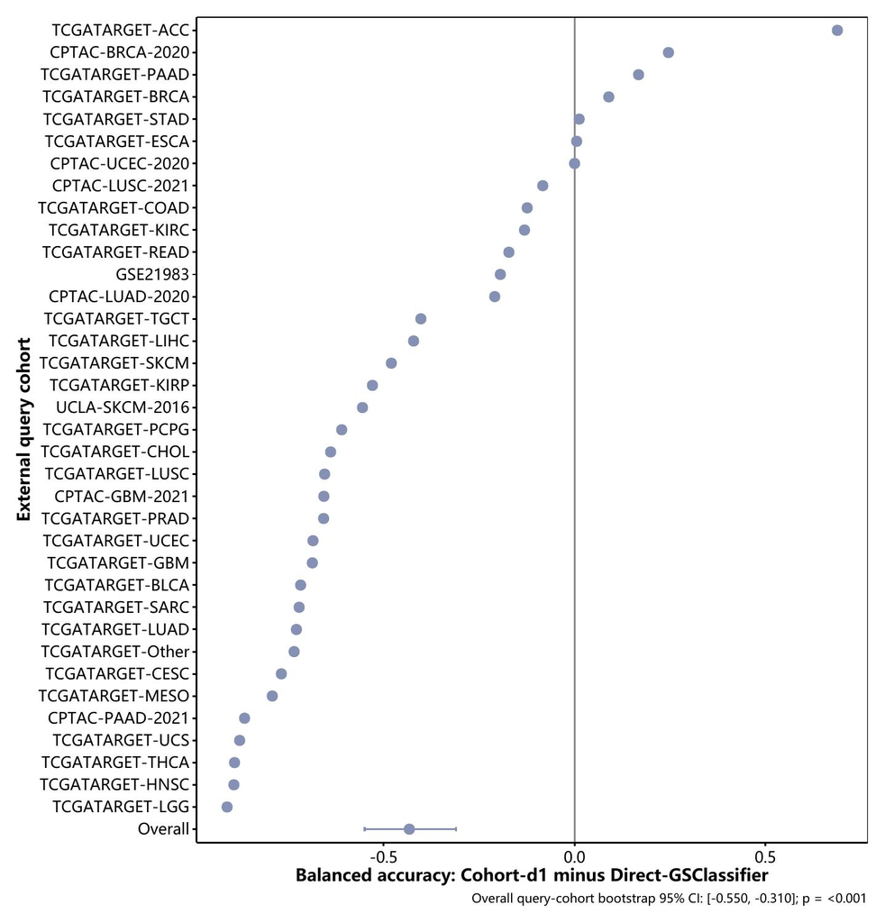

```r
knitr::include_graphics(fig3_jpg)
```

本次 readout 结果的直接解读是：使用全部 reference cohorts 时，Direct-GSClassifier 的外部 balanced accuracy 为 0.367，即各癌种召回率平均约为 36.7%；Cohort-d1 为 0.230，约为 23.0%。**d1 减 Direct 的总体差为 -0.137，即下降 13.7 个百分点。**

当前数据中，d1 表现最好的 readout cohort 是 TCGATARGET-ACC（差值 0.688），表现最差的是 TCGATARGET-LGG（差值 -0.910）。**这一 cohort 间差异表明，总体下降并不是所有 cohort 等幅变化。** 该比较采用 3-fold grouped CV，两种表示使用相同的预处理流程和调参预算，保证了比较口径一致。结果不支持“d1 能让低复杂度模型更容易利用旧癌种标签”这一狭义主张；至于它是否更有利于读出 ICI response、pathway state 或新的 pan-cancer subtype，本实验尚无法回答。

## 8 癌种 readout 的样本效率

总体分数较低可能来自表示缺少可用的旧癌种信息，也可能只是训练样本不足。学习曲线把可用于训练的 reference cohorts 比例依次设为 10%、25%、50%、100%；横轴不是“随机抽取多少样本”，而是“允许模型看到多少比例的 reference cohorts”。若 d1 与 Direct 的差距随训练比例增加而趋近零，问题更偏向样本效率；若点估计持续远离零，则更像表示本身改变了可读信息。两臂每次共享相同 cohort subset 和同一批 query，确保比较的不是题目难度。

每个点是 3 次配对重复的均值，阴影改为按 design repeat 做 cluster bootstrap 得到的 95% CI；它表达重复设计下均值的不确定性，不表示 95% 的单个 query 样本都落在阴影内。若有效重复数不足，推断表会标记为 `not_estimable`，不把近似区间当作确认性显著性检验。

### 8.1 学习曲线差异的重复设计推断

每个训练比例的统计单位是共享 cohort subset 的 design repeat，而不是其中的 query 样本。由于当前重复数由实验配置决定，结果表同时保留有效重复数和 `status`；重复不足时显示 `not_estimable`，不将近似区间当作确认性显著性证据。

```r
learning_inference_table <- learning_inference[, c(
  "requested_fraction", "estimate", "ci_low", "ci_high", "p_value", "p_value_adj",
  "n_cohort", "n_sample", "resamples", "unit", "multiplicity_method", "status"
)]
render_dt(learning_inference_table, pageLength = nrow(learning_inference_table))
```

|  | requested_fraction | estimate | ci_low | ci_high | p_value | p_value_adj | n_cohort | n_sample | resamples | unit | multiplicity_method | status |
| --- | --- | --- | --- | --- | --- | --- | --- | --- | --- | --- | --- | --- |
| 1 | 0.1 | -0.02144415035229584 |  |  |  |  | 3 | 3 | 2000 | design_repeat | holm | not_estimable |
| 2 | 0.25 | -0.04100719015355696 |  |  |  |  | 3 | 3 | 2000 | design_repeat | holm | not_estimable |
| 3 | 0.5 | -0.1018238391323901 |  |  |  |  | 3 | 3 | 2000 | design_repeat | holm | not_estimable |
| 4 | 1 | -0.1368674304000222 |  |  |  |  | 3 | 3 | 2000 | design_repeat | holm | not_estimable |

结论：该表显示每个训练比例的差异及其区间，并表明这些差异应归因到共享 cohort subset 的 design repeat，而非 query 样本数。

#### 8.1.1 学习曲线推断结果解读

在 100% reference fraction 的主要比较点，d1−Direct 差异为 -0.137，95% CI 为 [ NA, NA]，p = NA。该 CI 反映共享 cohort subset 的重复设计不确定性；其余 fraction 的校正 p 值用于样本效率敏感性分析，不能与主要终点等量齐观，也不能据此宣称端到端 refit 的确认性证据。

100% fraction 的有效 design repeat 数为 3，重复数偏少时 p 值分辨率有限，报告中的 status 会保留这一限制。

```r
# ==== Figure 4: Paired learning curves (user-adjustable parameters) ====
fig4 <- list(
  width_in = 6.8,
  height_in = 4.4,
  base_size = 11,
  line_size = 0.9,
  point_size = 2.5,
  point_alpha = 0.9,
  legend_position = "bottom"
)
p4 <- ggplot2::ggplot(
  learning_summary,
  ggplot2::aes(
    x = .data$requested_fraction,
    y = .data$estimate,
    color = .data$representation,
    group = .data$representation
  )
) +
  ggplot2::geom_ribbon(
    ggplot2::aes(
      ymin = .data$ci_low_rep,
      ymax = .data$ci_high_rep,
      fill = .data$representation
    ),
    alpha = 0.14,
    color = NA
  ) +
  ggplot2::geom_line(linewidth = fig4$line_size) +
  ggplot2::geom_point(size = fig4$point_size, alpha = fig4$point_alpha) +
  ggplot2::scale_x_continuous(
    breaks = manifest$config$validation$learning_fractions,
    labels = scales::label_percent(accuracy = 1)
  ) +
  ggplot2::scale_color_manual(
    values = c(
      "Direct-GSClassifier" = nature_colors[["blue"]],
      "Cohort-d1" = nature_colors[["red"]]
    )
  ) +
  ggplot2::scale_fill_manual(
    values = c(
      "Direct-GSClassifier" = nature_colors[["blue"]],
      "Cohort-d1" = nature_colors[["red"]]
    )
  ) +
  ggplot2::labs(
    x = "Fraction of reference cohorts",
    y = "External balanced accuracy",
    color = "Representation",
    fill = "Representation",
    caption = paste0(
      "Shaded bands: representation-specific repeat-bootstrap 95% CI; ",
      "primary paired p (100% fraction) = ",
      fmt_p(learning_inference$p_value[learning_inference$requested_fraction == 1])
    )
  ) +
  theme_nature_readable(
    base_size = fig4$base_size,
    x_text_angle = 0,
    legend_position = fig4$legend_position
  )

# Readability check: four x ticks remain sparse, ribbons carry cohort/design-repeat
# bootstrap uncertainty, and the external legend avoids covering either curve.
fig4_jpg <- .ae_save_plot(
  p4, "figure-04-paired-learning-curve", figure_dir,
  preview_dir, fig4, params$plot_preview_dpi
)
```

```
## Converting page 1 to E:/RCloud/RFactory/ccs/test/ablation-02/tmp/plot-previews/02-ablation-experiment-20260829223955/figure-04-paired-learning-curve.jpg... done!
```

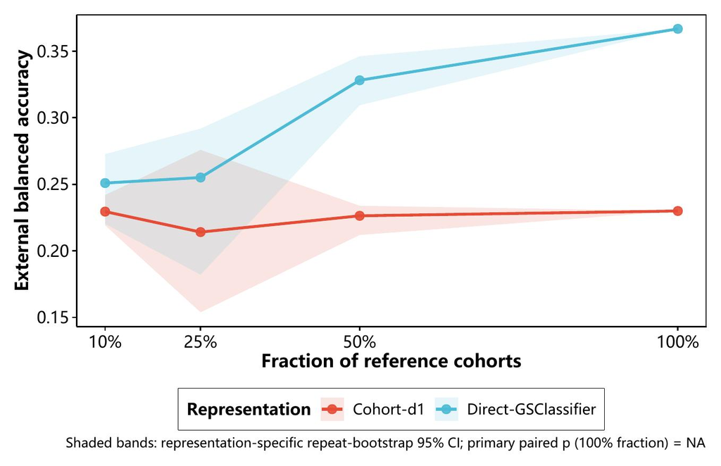

```r
knitr::include_graphics(fig4_jpg)
```

本次学习曲线的直接解读是：在上述四个训练比例下，d1 相对 Direct 的癌种 balanced-accuracy 点估计差依次为 -0.021, -0.041, -0.102, -0.137。差值从最低训练比例时的 -0.021 扩大到全部 reference cohorts 时的 -0.137，**没有出现“数据增加后差距回到零”的点估计模式**。这不支持差距仅由小训练集造成，但 3 次重复仍不足以把学习曲线当作严格显著性证据。每个比例下两种表示共享 cohort subset hash 和外部 query hash，因此差异也不能归因于训练组成或测试样本漂移；这条曲线只衡量 cancer-type readout，不能据此认定 d1 对所有新分型任务都存在“过度压缩”。

## 9 主要终点的效应量与不确定性

这张综合图把三个分析模块的主要或预先指定比较点放在同一条零差异基线上。横轴始终是 d1−Direct，因此不同指标的绝对数值只用于判断各自区间是否跨零，不把不同量纲的效应大小直接横向排名。

```r
# ==== Figure 10: Inference summary forest plot (user-adjustable parameters) ====
fig10 <- list(
  # Canvas size in inches. Increase height if endpoint labels become crowded.
  width_in = 7.2,
  height_in = 4.6,
  base_size = 10,
  point_size = 2.8,
  line_size = 0.75,
  zero_line_width = 0.55,
  legend_position = "none"
)
p10 <- ggplot2::ggplot(
  forest_data,
  ggplot2::aes(y = .data$endpoint, x = .data$estimate)
) +
  ggplot2::geom_vline(
    xintercept = 0,
    linewidth = fig10$zero_line_width,
    linetype = "dashed",
    color = "grey55"
  ) +
  ggplot2::geom_errorbar(
    ggplot2::aes(xmin = .data$ci_low, xmax = .data$ci_high),
    orientation = "y",
    linewidth = fig10$line_size,
    na.rm = TRUE
  ) +
  ggplot2::geom_point(
    size = fig10$point_size,
    color = nature_colors[["purple"]],
    na.rm = TRUE
  ) +
  ggplot2::labs(
    x = "Cohort/query-level d1 minus Direct estimate",
    y = NULL,
    caption = paste0(
      "Points: estimates; lines: 95% bootstrap CI; dashed line: zero difference; ",
      "p = ", fmt_p(forest_data$p_value)
    )
  ) +
  theme_nature_readable(
    base_size = fig10$base_size,
    x_text_angle = 0,
    legend_position = fig10$legend_position
  )

# Readability check: endpoints are short and ordered by analysis module; the
# horizontal intervals expose zero-crossing directly without overlapping labels.
fig10_jpg <- .ae_save_plot(
  p10, "figure-10-inference-summary", figure_dir, preview_dir, fig10,
  params$plot_preview_dpi
)
```

```
## Converting page 1 to E:/RCloud/RFactory/ccs/test/ablation-02/tmp/plot-previews/02-ablation-experiment-20260829223955/figure-10-inference-summary.jpg... done!
```

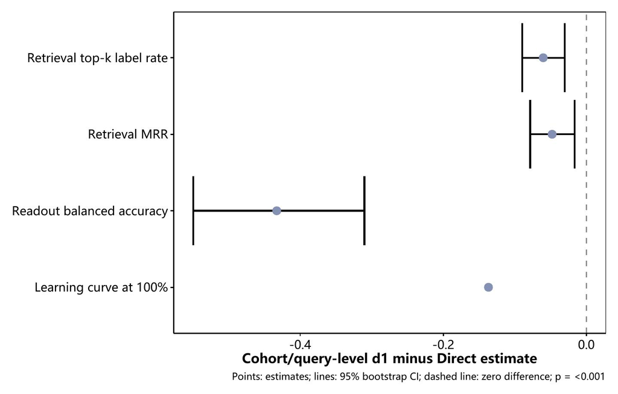

```r
knitr::include_graphics(fig10_jpg)
```

## 10 cohort evidence 的二维 scaling

上一节改变 readout 可使用的 reference cohorts，本节固定 reference/query 抽样和冻结模型，只改变进入 d1 的 cohort evidence 组成。所有 bank 共用同一组分层抽取的 5000 个 reference 与 2000 个 query，样本不会被当作 scaling 重复。`breadth` sequence 固定每个 tissue 一个 cohort，逐步增加 tissue；`depth` sequence 固定 tissue 集合，逐层增加每个 tissue 的 cohort；`matched` design 则在完全相同的 module 总数下直接比较 breadth-heavy 与 depth-heavy bank。`cohort_scaling.rds` 共保存 140 个可审计 bank，并记录 5 个不可行设计及原因。

这样拆分 breadth 和 depth，是为了分别评估新增组织背景与同组织新增独立队列的贡献，而不是只看 module 总数。本节并列检查三种性质，它们回答的问题不同。

Normalized effective rank 衡量 d1 中“真正被使用的信息方向占可用方向的比例”。先对中心化 d1 做奇异值分解，把第 $j$ 个方向的能量占比记为 $p_j=s_js_j/\sum_\ell s_\ell s_\ell$，再计算

$$\operatorname{EffectiveRank}=\exp\left(-\sum_j p_j\log p_j\right),$$

最后除以该 bank 理论上可容纳的最大秩，即 query 样本数减一与 d1 列数中的较小者。若能量平均分布在许多方向上，normalized effective rank 接近一；若大部分变化挤在少数方向上，它就下降。因为这里报告的是“有效方向占容量的比例”，下降不等于原有方向凭空消失，也可能是新增 modules 扩大容量的速度快于新增独立信息的速度。

```r
# ==== Figure 8: Breadth and depth scaling (user-adjustable parameters) ====
fig8 <- list(
  # A wide canvas keeps the 3 x 2 facet labels readable without abbreviation.
  width_in = 8.2,
  height_in = 6.4,
  base_size = 10,
  # Lines carry repeat means; points keep sparse feasible grid cells visible.
  line_size = 0.85,
  point_size = 2.2,
  point_alpha = 0.90,
  ribbon_alpha = 0.14,
  legend_position = "bottom"
)
p8 <- ggplot2::ggplot(
  scaling_sequence,
  ggplot2::aes(
    x = .data$scaling_axis,
    y = .data$estimate,
    color = .data$design_label,
    fill = .data$design_label,
    group = .data$design_label
  )
) +
  ggplot2::geom_ribbon(
    ggplot2::aes(
      ymin = .data$ci_low_seq,
      ymax = .data$ci_high_seq
    ),
    alpha = fig8$ribbon_alpha,
    color = NA
  ) +
  ggplot2::geom_line(linewidth = fig8$line_size) +
  ggplot2::geom_point(
    size = fig8$point_size,
    alpha = fig8$point_alpha
  ) +
  ggplot2::facet_grid(
    rows = ggplot2::vars(.data$metric_label),
    cols = ggplot2::vars(.data$design_label),
    scales = "free"
  ) +
  ggplot2::scale_color_manual(values = c(
    "Tissue breadth" = nature_colors[["blue"]],
    "Within-tissue depth" = nature_colors[["red"]]
  )) +
  ggplot2::scale_fill_manual(values = c(
    "Tissue breadth" = nature_colors[["blue"]],
    "Within-tissue depth" = nature_colors[["red"]]
  )) +
  ggplot2::labs(
    x = "Added tissues or cohort-depth level",
    y = "Estimate",
    color = "Bank design",
    fill = "Bank design",
    caption = "Shaded bands: design-repeat bootstrap 95% CI; slope p-values are reported in the table below"
  ) +
  theme_nature_readable(
    base_size = fig8$base_size,
    x_text_angle = 0,
    legend_position = fig8$legend_position
  )

# Readability check: each scientific property receives its own y scale, breadth
# and depth never share an ambiguous x definition, and the external legend leaves
# all sparse feasible cells unobstructed.
fig8_jpg <- .ae_save_plot(
  p8, "figure-08-cohort-evidence-sequences", figure_dir,
  preview_dir, fig8, params$plot_preview_dpi
)
```

```
## Converting page 1 to E:/RCloud/RFactory/ccs/test/ablation-02/tmp/plot-previews/02-ablation-experiment-20260829223955/figure-08-cohort-evidence-sequences.jpg... done!
```

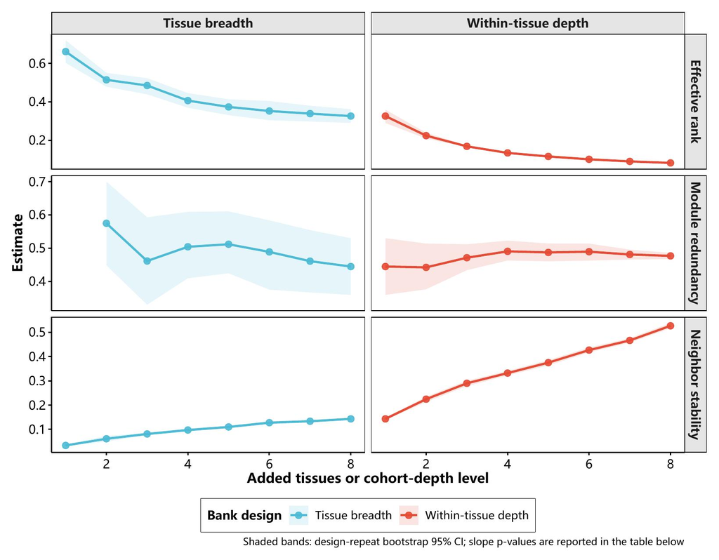

```r
knitr::include_graphics(fig8_jpg)
```

Figure 8 的阴影区间现在按每个 scaling cell 的 design repeat 重新抽取计算。结果解读：它显示同一 bank 设计在不同重复下的估计范围，并表明不同设计的差异不应由 query 数量解释；它不把同一 repeat 内的多个 query 当作独立样本。区间较宽时，说明当前独立 bank-design repeats 对该 scaling cell 的估计仍不稳定。

```r
scaling_inference_table <- scaling_inference[, c(
  "contrast_type", "metric_name", "estimate", "ci_low", "ci_high",
  "p_value", "p_value_adj", "n_cohort", "unit", "status", "reason"
)]
render_dt(scaling_inference_table, pageLength = nrow(scaling_inference_table))
```

|  | contrast_type | metric_name | estimate | ci_low | ci_high | p_value | p_value_adj | n_cohort | unit | status | reason |
| --- | --- | --- | --- | --- | --- | --- | --- | --- | --- | --- | --- |
| 1 | breadth_depth_interaction | cka_to_full_d1 | 0.0001382143043620967 | -1.068628046994095e-05 | 0.0002965916160360333 | 0.2121212121212121 | 1 | 5 | design_repeat | exploratory | fewer_than_ten_independent_design_repeats |
| 2 | breadth_depth_interaction | distance_spearman_to_full_d1 | 0.0001386071530475857 | -0.0001709819226820222 | 0.0004481962287771936 | 0.5151515151515151 | 1 | 5 | design_repeat | exploratory | fewer_than_ten_independent_design_repeats |
| 3 | breadth_depth_interaction | knn_jaccard_to_full_d1 | 0.003844442628318134 | 0.003738748179552491 | 0.003950137077083777 | 0.09090909090909091 | 1 | 5 | design_repeat | exploratory | fewer_than_ten_independent_design_repeats |
| 4 | breadth_depth_interaction | lineage_balanced_accuracy_d1 | 0.00018769722228141 | 9.433385512084928e-06 | 0.0003936267023524686 | 0.2121212121212121 | 1 | 5 | design_repeat | exploratory | fewer_than_ten_independent_design_repeats |
| 5 | breadth_depth_interaction | lineage_macro_auroc_d1 | 0.0001441695918252033 | 2.601890827340957e-06 | 0.0002791083930925575 | 0.2727272727272727 | 1 | 5 | design_repeat | exploratory | fewer_than_ten_independent_design_repeats |
| 6 | breadth_depth_interaction | lineage_mrr@15 | 0.0001388005518749069 | -1.067505394233648e-05 | 0.0002605104496556301 | 0.2121212121212121 | 1 | 5 | design_repeat | exploratory | fewer_than_ten_independent_design_repeats |
| 7 | breadth_depth_interaction | lineage_mrr@30 | 0.0001388005518749069 | -1.067505394233648e-05 | 0.0002663848929556723 | 0.2121212121212121 | 1 | 5 | design_repeat | exploratory | fewer_than_ten_independent_design_repeats |
| 8 | breadth_depth_interaction | lineage_mrr@5 | 0.0001388005518749069 | -1.067505394233648e-05 | 0.0002548848837321864 | 0.2121212121212121 | 1 | 5 | design_repeat | exploratory | fewer_than_ten_independent_design_repeats |
| 9 | breadth_depth_interaction | lineage_top_k@15 | 0.0001587135970788668 | 2.824736457227503e-05 | 0.0003135383637538669 | 0.1515151515151515 | 1 | 5 | design_repeat | exploratory | fewer_than_ten_independent_design_repeats |
| 10 | breadth_depth_interaction | lineage_top_k@30 | 0.0001422014342708668 | 1.366889478495824e-05 | 0.0002762036107266131 | 0.2727272727272727 | 1 | 5 | design_repeat | exploratory | fewer_than_ten_independent_design_repeats |

[output cut: 90 more lines]

本次 scaling sequence 的结果显示：normalized effective rank 的 breadth 斜率为 **-0.044**（repeat-bootstrap 95% CI -0.049 至 -0.036），depth 斜率为 **-0.031**（95% CI -0.035 至 -0.027）。两条置信区间均低于零，表明每新增一个 tissue 或每增加一层同 tissue cohort，非重复方向占当前 bank 容量的比例都在下降；按斜率量级，分别约下降 4.4 和 3.1 个百分点。这说明新增 evidence 没有按 module 容量同比增加独立方向，但不能据此断言 raw effective rank 一定下降。

作为配套检查，module redundancy 的 breadth/depth 斜率分别为 -0.014（95% CI -0.024 至 -0.006）和 0.006（-0.006 至 0.016）。Breadth 区间完全低于零，表示加入更多 tissues 时 module 间平均绝对相关性下降；depth 的区间跨零，尚未显示重复性稳定增减。Neighbor stability 的 breadth/depth 斜率分别为 0.015（0.014 至 0.016）和 0.052（0.050 至 0.053），两条区间都高于零，说明两种扩展都提高了邻域稳定性；由于两条轴单位不同，不比较斜率大小。

三项指标合看，**effective-rank 比例下降并没有伴随邻域不稳定：新增 evidence 让不同 bank 抽样得到的邻居更一致，但新增独立方向没有跟上容量扩张。** Breadth 还减少了 module 间的线性重复，说明其新增证据并非简单复制；更准确的解释是，新方向的增量相对于不断扩大的 bank 容量逐渐变小，而不是新增 modules 只带来不稳定噪声。

上一张图的 breadth 和 depth 使用不同横轴单位，不能直接拿斜率大小判胜负。所以下一张 matched-size 图锁定完全相同的 module 总数，再比较 breadth-heavy 与 depth-heavy 的 evidence 分配方式。

```r
# ==== Figure 9: Matched-size breadth versus depth (user-adjustable parameters) ====
fig9 <- list(
  width_in = 8.2,
  height_in = 5.2,
  base_size = 10,
  line_size = 0.85,
  point_size = 2.3,
  point_alpha = 0.92,
  ribbon_alpha = 0.15,
  zero_line_width = 0.55,
  legend_position = "none"
)
p9 <- ggplot2::ggplot(
  scaling_matched,
  ggplot2::aes(x = .data$module_count, y = .data$estimate)
) +
  ggplot2::geom_hline(
    yintercept = 0,
    linewidth = fig9$zero_line_width,
    color = "grey55"
  ) +
  ggplot2::geom_ribbon(
    ggplot2::aes(
      ymin = .data$ci_low_matched,
      ymax = .data$ci_high_matched
    ),
    fill = nature_colors[["green"]],
    alpha = fig9$ribbon_alpha
  ) +
  ggplot2::geom_line(
    linewidth = fig9$line_size,
    color = nature_colors[["green"]]
  ) +
  ggplot2::geom_point(
    size = fig9$point_size,
    alpha = fig9$point_alpha,
    color = nature_colors[["green"]]
  ) +
  ggplot2::facet_wrap(ggplot2::vars(.data$metric_label), scales = "free_y") +
  ggplot2::scale_x_continuous(
    trans = "log2",
    breaks = sort(unique(scaling_matched$module_count))
  ) +
  ggplot2::labs(
    x = "Matched frozen cohort modules",
    y = "Breadth-heavy minus depth-heavy",
    caption = "Shaded bands: matched-size design-repeat bootstrap 95% CI"
  ) +
  theme_nature_readable(
    base_size = fig9$base_size,
    x_text_angle = 45,
    legend_position = fig9$legend_position
  )

# Readability check: the zero reference line makes direction explicit, free y
# scales prevent small stability differences being flattened, and 45-degree x
# labels separate the dense 75/100/125-module ticks without hiding grid cells.
fig9_jpg <- .ae_save_plot(
  p9, "figure-09-cohort-evidence-matched", figure_dir,
  preview_dir, fig9, params$plot_preview_dpi
)
```

```
## Converting page 1 to E:/RCloud/RFactory/ccs/test/ablation-02/tmp/plot-previews/02-ablation-experiment-20260829223955/figure-09-cohort-evidence-matched.jpg... done!
```

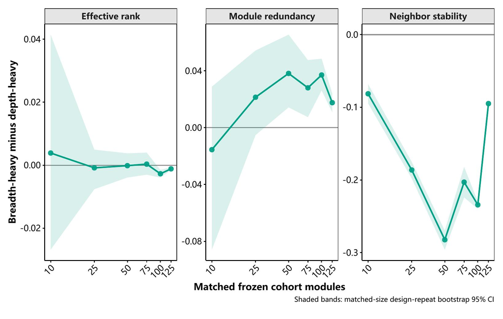

```r
knitr::include_graphics(fig9_jpg)
```

Matched-size 结果显示的是“breadth-heavy 减 depth-heavy”的配对差异。这里锁定的是 module 预算，不要求三列或四列输出的 d1 总列数完全相同；前述 module-balanced 距离确保宽 block 不会因此获得更大权重。Effective rank 和 stability 的正值偏向 breadth-heavy；redundancy 则相反，负值才表示 breadth-heavy 的重复信息更少。本次 normalized effective rank 差为 -0.000（95% CI -0.006 至 0.005），接近零且区间跨零，**没有显示相同 module 数下 breadth-heavy 拥有更高非重复方向比例**。

Module redundancy 差为 0.021（95% CI 0.009 至 0.033），区间完全高于零，即 breadth-heavy 的平均绝对 module 相关性高出约 2.1 个百分点；neighbor stability 差为 -0.180（95% CI -0.184 至 -0.177），区间完全低于零，即 breadth-heavy 的邻居重合低约 18.0 个百分点。**在当前 matched-size 设计中，breadth-heavy 没有表现出更高 effective rank，反而更冗余且邻域更不稳定；现有证据不支持仅靠扩大 tissue breadth 就能改善这三项内部性质。** 这与 sequence 中“沿 breadth 路径增加 tissue 时 redundancy 下降”并不矛盾：sequence 问同一路径随 bank 变大如何变化，matched-size 问相同 module 预算下两种组成谁更高，两者的参照组不同。所有区间以 5 个 bank-design repeats 为重采样单位，未把同一 repeat 内的多个 grid cells 或 query 样本误作独立重复；只有 5 个 repeats，因此区间仍需谨慎解释。

独立外部生物效用当前标记为 **not_evaluated**，原因为 no_independent_biology_anchor_configured。因此，二维结果只能说明当前 150-module 冻结 bank 内部的组成性质；即便最大 bank 附近出现平台，也不能推断 cohort congress 在 150 个 modules 达到普遍饱和，更不能外推到尚未训练的新 cohort models。Cancer-type balanced accuracy、macro-AUROC、top-k 和 MRR 继续保存在 `metrics` 中，但统一标记为 `diagnostic_lineage`，不进入 CCS 成败判断。

## 11 技术来源与癌种锚点的联合评估

模型可能只是按测序平台、assay 或数据来源把样本分堆，而不是学到可迁移的生物结构。为避免“某癌种本来就主要来自某个平台”被误判成模型偏好，technical-neighbor excess 分三步计算：先在技术标签有效的 query 邻居中求同技术来源的实际比例；再在“其他 cohorts、同癌种”的有效 reference 中计算同技术来源的背景比例；最后用“实际比例减背景比例”得到 excess。excess 为零表示观察到的技术聚集可由癌种构成解释，正值表示仍有额外同技术聚集，负值表示比背景预期更少。图中每个点先在一个 cohort 内对样本 excess 差取平均，正文所报三个总体值再对这些 cohort 点等权平均。

图中进一步计算

$$\Delta\operatorname{Excess}=
\operatorname{Excess}_{d1}-\operatorname{Excess}_{Direct}.$$

因此负差值表示 d1 减少了 Direct 中超出癌种构成所能解释的技术邻居聚集，正差值表示技术边界增强。例如负十分之一表示额外同技术邻居率下降十个百分点。该指标用于识别技术痕迹是否减弱，但不能单独证明批次效应已彻底消除。

```r
# ==== Figure 5: Technical-neighbor excess deltas (user-adjustable parameters) ====
fig5 <- list(
  width_in = 6.8,
  height_in = 4.2,
  base_size = 10,
  point_size = 1.8,
  point_alpha = 0.72,
  jitter_width = 0.12,
  jitter_seed = 20260807L,
  zero_line_width = 0.55,
  legend_position = "none"
)
p5 <- ggplot2::ggplot(
  technical_delta,
  ggplot2::aes(
    x = .data$technical_factor,
    y = .data$estimate,
    color = .data$technical_factor
  )
) +
  ggplot2::geom_hline(
    yintercept = 0,
    linewidth = fig5$zero_line_width,
    color = "grey55"
  ) +
  ggplot2::geom_boxplot(outlier.shape = NA, width = 0.5, alpha = 0.2) +
  ggplot2::geom_jitter(
    position = ggplot2::position_jitter(
      width = fig5$jitter_width,
      height = 0,
      seed = fig5$jitter_seed
    ),
    size = fig5$point_size,
    alpha = fig5$point_alpha
  ) +
  ggplot2::scale_color_manual(
    values = unname(nature_colors[seq_along(technical_columns)])
  ) +
  ggplot2::labs(
    x = "Technical factor",
    y = "Delta in same-technology excess",
    color = "Technical factor"
  ) +
  theme_nature_readable(
    base_size = fig5$base_size,
    x_text_angle = 0,
    legend_position = fig5$legend_position
  )

# Readability check: factor labels are short, jitter exposes cohort heterogeneity,
# and a horizontal zero line separates reduced from increased technical clustering;
# the redundant color legend is removed because the x-axis already names each factor.
fig5_jpg <- .ae_save_plot(
  p5, "figure-05-technical-neighbor-excess", figure_dir,
  preview_dir, fig5, params$plot_preview_dpi
)
```

```
## Converting page 1 to E:/RCloud/RFactory/ccs/test/ablation-02/tmp/plot-previews/02-ablation-experiment-20260829223955/figure-05-technical-neighbor-excess.jpg... done!
```

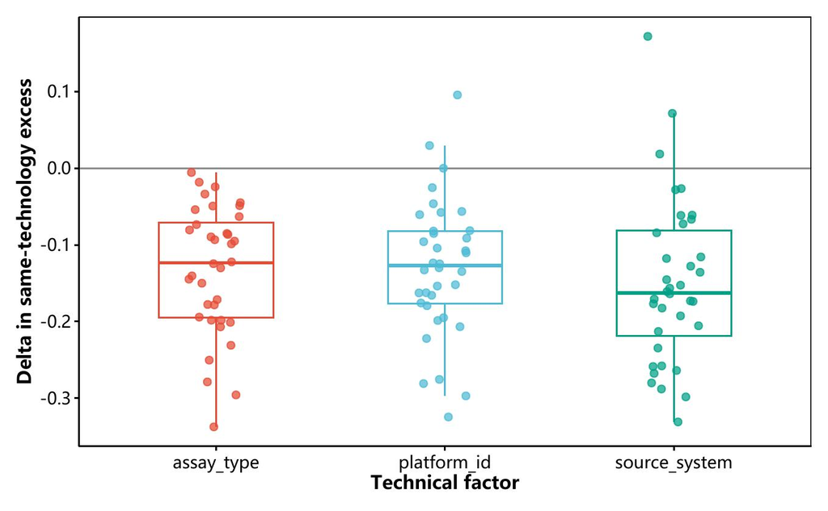

```r
knitr::include_graphics(fig5_jpg)
```

本次 technical-excess 结果的直接解读是：在同一 cancer_type 背景内校正后，三个技术因子的均值差分别为 assay_type = -0.133; platform_id = -0.130; source_system = -0.150。三者均为负值，意味着 assay、platform 和 source 的额外邻居聚集分别减少约 13.3、13.0、15.0 个百分点；这是本轮实验中支持 cohort-conditioned integration 的**最强正向信号**。与此同时，癌种一致率也从 0.437 降至 0.358，表明技术边界减弱与去癌种中心化同时发生。

但这里的“背景校正”只控制了 cancer_type 的总体组成，没有控制全部潜在生物差异，也没有证明每个 cohort 都同向变化。由于 cancer type 仍是粗粒度锚点，现有数据无法区分“保留共享肿瘤状态的有目的融合”和“无选择混合”。因此，technical excess 的下降可作为机制线索，但不足以断言 batch removal 已经成功，也不能反向认定生物信号已被抹平。

## 12 module 贡献的集中程度

d1 汇总了 150 个 module，但它们不一定贡献相同。对本节同一批 reference 样本的原始、未标准化 d1，本报告先计算每个 module 各概率输出列的样本间方差，再取该 module 的列方差平均；随后用其平均方差除以全部 modules 平均方差的总和，得到 variance share。所有 shares 加起来等于一：某个 module 的 share 越高，说明它在“每个 module 先等权汇总”的变化量池中占比越大。它不等于所有 d1 原始列总方差的直接份额，也不是因果重要性、信息量或任务贡献。

```r
# ==== Figure 6: d1 module variance concentration (user-adjustable parameters) ====
fig6 <- list(
  width_in = 7.2,
  height_in = 5.8,
  base_size = 9,
  bar_width = 0.72,
  legend_position = "none"
)
module_top$module_label <- .ae_resolve_module_labels(
  module_top$module_id,
  data_profile$resolution_audit
)
module_top$module_label <- factor(
  module_top$module_label,
  levels = rev(module_top$module_label)
)
p6 <- ggplot2::ggplot(
  module_top,
  ggplot2::aes(x = .data$variance_share, y = .data$module_label)
) +
  ggplot2::geom_col(
    width = fig6$bar_width,
    fill = nature_colors[["green"]]
  ) +
  ggplot2::scale_x_continuous(labels = scales::label_percent(accuracy = 0.1)) +
  ggplot2::labs(x = "Share of module-level variance", y = "Frozen cohort module") +
  theme_nature_readable(
    base_size = fig6$base_size,
    x_text_angle = 0,
    legend_position = fig6$legend_position
  )

# Readability check: only the top 20 modules are labeled, horizontal bars protect
# tissue|cohort names from clipping, and the vector PDF preserves small text.
fig6_jpg <- .ae_save_plot(
  p6, "figure-06-module-variance-concentration", figure_dir,
  preview_dir, fig6, params$plot_preview_dpi
)
```

```
## Converting page 1 to E:/RCloud/RFactory/ccs/test/ablation-02/tmp/plot-previews/02-ablation-experiment-20260829223955/figure-06-module-variance-concentration.jpg... done!
```

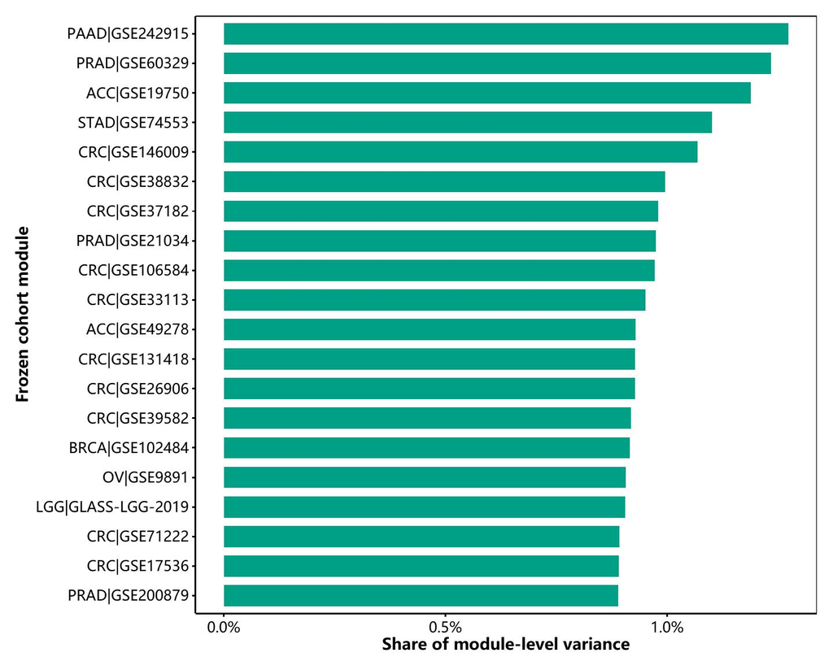

```r
knitr::include_graphics(fig6_jpg)
```

本次 module 方差结果显示：贡献最高的 PAAD|GSE242915 占 1.3%，前 10 个 modules 合计占 10.7%。若 150 个 modules 完全均匀，单个 module 和前 10 个的参考份额分别约为 0.7% 与 6.7%；当前两个头部份额均高于这一均匀参照，表明变化量确有一定集中。但最高单体只占 1.3%，**当前结果并不是由某一个 module 完全支配**。

图中历史遗留的 `Undefined|cohort` 只在显示层被替换为已核验的真实 tissue，底层 module ID、模型路径和审计哈希均未改变。d1 block 的宽度范围为 3–4；距离计算已经按 block 宽度和 module 数做等权处理，所以观察到的集中度来自概率输出分布，而不是“列数越多，权重自然越大”。下一步应把 variance-share 排名前列的 modules 与 retrieval、readout 或独立生物锚点的增量贡献做配对消融；只有高 share 同时对应稳定任务增益，才能把“变化多”进一步解释为“有用”。

## 13 输入信息压缩与可恢复性

最后检查 d1 压缩后还能恢复多少 Direct 原始线索。Decoder 先在 reference d1 上保留 50 个主方向，再用带惩罚系数 $\lambda=$ 1 的 ridge 线性模型重建完整 Direct features，最后只在外部 query 上评分。它回答的是“Direct 中哪些线索还能从 d1 线性恢复”，不是重新训练一个癌种分类器。

三种 feature 输出类型不同，不能共用一个损失函数。Gene-pair 是零/一变量：ridge 输出先截断到零至一作为概率，再以二分之一为阈值计算 balanced accuracy；Brier score 是截断概率与真实零/一值之差的平方平均，零表示概率完全正确，越大表示概率越不准。Single-bin 和 set-pair 是连续量：Spearman 比较真实值与重建值的高低名次，接近一表示排序保留好；MAE 是绝对误差平均值，RMSE 是平方误差平均后开根号，后者会更重地惩罚少数大误差，两者都越低越好。本报告按既定 feature contract 为 single-bin 展示 MAE、为 set-pair 展示 RMSE，这只是分别描述典型绝对误差与大误差敏感误差，不表示其中一种误差天然更适合某类生物线索。所有指标先逐 feature 计算，再在同一 feature type 内等权平均；不同类型和不同原量纲之间不能横向比较。图中为了让柱子统一朝“越高越好”的方向展示，对 MAE/RMSE 采用“误差加一后取倒数”的变换；正文仍报告原始误差，不能把变换后的柱高误读成 accuracy。

```r
# ==== Figure 7: Feature-type reconstruction metrics (user-adjustable parameters) ====
fig7 <- list(
  width_in = 7.0,
  height_in = 4.2,
  base_size = 10,
  bar_width = 0.68,
  legend_position = "bottom"
)
decoder_plot <- rbind(
  data.frame(
    feature_type = "gene_pair",
    metric = c("Balanced accuracy", "1 - Brier"),
    value = c(
      decoder_summary$balanced_accuracy[decoder_summary$feature_type == "gene_pair"],
      1 - decoder_summary$brier[decoder_summary$feature_type == "gene_pair"]
    )
  ),
  data.frame(
    feature_type = "single_bin",
    metric = c("Spearman", "1 / (1 + MAE)"),
    value = c(
      decoder_summary$spearman[decoder_summary$feature_type == "single_bin"],
      1 / (1 + decoder_summary$mae[decoder_summary$feature_type == "single_bin"])
    )
  ),
  data.frame(
    feature_type = "set_pair",
    metric = c("Spearman", "1 / (1 + RMSE)"),
    value = c(
      decoder_summary$spearman[decoder_summary$feature_type == "set_pair"],
      1 / (1 + decoder_summary$rmse[decoder_summary$feature_type == "set_pair"])
    )
  )
)
p7 <- ggplot2::ggplot(
  decoder_plot,
  ggplot2::aes(x = .data$feature_type, y = .data$value, fill = .data$metric)
) +
  ggplot2::geom_col(
    position = "dodge",
    width = fig7$bar_width
  ) +
  ggplot2::scale_fill_manual(values = unname(nature_colors[seq_len(6L)])) +
  ggplot2::scale_y_continuous(limits = c(0, 1.02), breaks = seq(0, 1, 0.2)) +
  ggplot2::labs(
    x = "Direct feature type",
    y = "Reconstruction score",
    fill = "Metric"
  ) +
  theme_nature_readable(
    base_size = fig7$base_size,
    x_text_angle = 0,
    legend_position = fig7$legend_position
  )

# Readability check: six color-blind-safe bars are separated by feature type;
# the legend is external and no heterogeneous raw loss is merged into one winner score.
fig7_jpg <- .ae_save_plot(
  p7, "figure-07-feature-type-reconstruction", figure_dir,
  preview_dir, fig7, params$plot_preview_dpi
)
```

```
## Converting page 1 to E:/RCloud/RFactory/ccs/test/ablation-02/tmp/plot-previews/02-ablation-experiment-20260829223955/figure-07-feature-type-reconstruction.jpg... done!
```

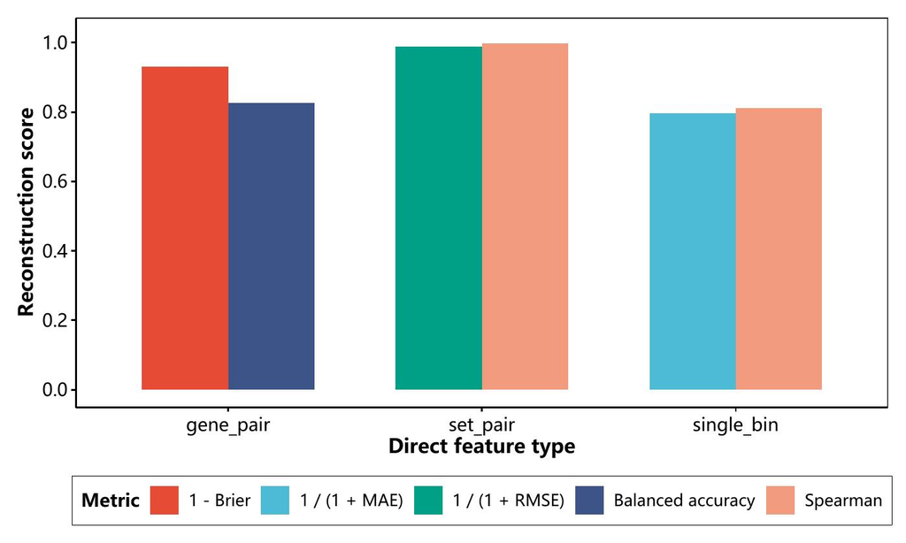

```r
knitr::include_graphics(fig7_jpg)
```

使用 d1 重建外部 query 的完整 Direct 输入时，gene-pair 的 balanced accuracy 为 0.826，明显高于二分类随机识别的 `0.5`；Brier 为 0.069，说明多数零/一概率线索可以较好恢复，但仍不是无误差重建。Single-bin 的 Spearman 为 0.811，表明样本高低排序保留较强，MAE 为 0.255，说明原量纲上仍存在不可忽略的绝对偏差。唯一一个 set-pair 的 Spearman/RMSE 为 0.998 / 0.012，接近无损，但单个 feature 不能代表整个类型的普遍表现。

这些结果共同说明：d1 保留了相当多的 Direct 排序与概率信息，却不是 Direct features 的可逆容器，且损失程度因 feature type 而异。真正需要判断的是，被压缩的究竟是队列/癌种捷径，还是新状态和下游任务所需的信息。下一步应按 per-feature decoder 误差锁定最难恢复的 gene-pair 和 single-bin，再与 pathway、TME 和 outcome 锚点对齐；若高误差 features 对独立生物任务并不重要，才更支持这是有目的的信息瓶颈。

Null 对照像把同一盒积木随便重排后再做一次实验，用来判断“任何乱变换都会出现同样结果”还是 d1 的特定构造才会出现。**Null-Perm** 尝试在每个 query cohort 内打乱癌种标签；只有同一 cohort 内至少存在两种标签时，置换才会真正改变数据。**Null-RP** 不使用 cohort models，而是把已经标准化的 Direct 乘以固定随机稀疏矩阵：约三分之二权重为零，其余为对称的正、负随机权重，再投影到 100 维并使用欧氏距离检索。本次使用 3 个随机种子，观察结论是否只是“任何同量级随机压缩”都会出现。这个 rank 是低维随机对照的预算，不宣称与 d1 的有效容量完全相同；Null-Perm 和 Null-RP 都不是候选方法，而是用于拆穿偶然现象的参照物。

Null-Perm 的资格状态为 **not_eligible**。36 个 query cohorts 的 cancer type 在各自 cohort 内保持不变，洗牌前后标签完全相同，因而无法形成有检验力的置换零分布；本报告据此不生成形式完整却实际无效的伪对照。在 $k=$ 30 时，3 组 Null-RP 的癌种一致率介于 0.403 和 0.413，均高于 d1 的 0.358。这不支持“本次采用的稀疏随机投影会以同等程度去癌种中心化”的解释，说明 d1 的 lineage 改写不能由这几组 Null-RP 完全解释，并与 cohort-model bank 的特定映射有关联；它不是排除其他机制后的因果证明。Null-RP 只能说明 d1 比这些随机投影更不利于恢复癌种；cohort bank 对发现新状态是否必要，仍需依靠与研究目标一致的 Null 对照及状态/任务指标判断。

## 14 讨论与分析

本次结果显示，在旧癌种标签恢复任务中，d1 的 top-k 一致率平均差为 -0.079，MRR 平均差为 -0.072，总体癌种 readout 差为 -0.137，三者相对 Direct 均为负值。即使使用全部训练数据，癌种学习曲线差仍为 -0.137，说明增加训练数据并未消除差距。因此，在恢复旧癌种标签这一任务上，Direct-GSClassifier 是更简单、表现也更好的表示。

从机制上看，当前最有证据支持的解释不是“d1 把癌种标签简单平均掉了”，而是 cohort bank 对同一份 Direct feature 进行了选择性的重编码和重新加权：同一样本被多个冻结 cohort 模型分别读取，d1 保存的是这些模型输出组成的证据向量，而不是某一个已知 cohort 的标签。几何指标显示这种重编码确实改变了局部邻域；同时，三个技术来源的 excess 均下降，说明与 cohort/技术来源相关的方向被削弱。由于部分 cancer type 与 cohort、assay 或 platform 绑定，技术边界减弱可能连带降低旧癌种标签的可恢复性。因此，“癌种信号被稀释”的直觉可以保留，但更准确的说法是：癌种相关方向被重新分散、降权，且其中一部分可能与技术或队列捷径重叠。

现有结果还不支持“所有信息都被无差别破坏”。d1 仍能较好地恢复相当一部分 Direct 的概率和排序信息，随机投影对照也没有产生同等幅度的癌种下降；这更像是与具体 cohort-model bank 有关的有方向信息瓶颈，而不是一般性的降维损失。另一方面，technical excess 的下降和癌种 readout 的下降同时出现，只能说明两种变化并存，不能证明被去除的正是技术噪声，也不能证明剩余空间已经携带有用的新生物状态。换言之，当前证据可以支持“d1 改写了表示并降低了旧癌种中心化”，但还不能在“有目的的泛癌重表达”和“无选择的信息混合”之间作出因果区分。

| 可能解释 | 目前支持度 | 主要依据 |
| --- | --- | --- |
| cohort-conditioned 重编码导致癌种中心化减弱 | 高 | 几何指标显示局部邻域被明显重排；癌种检索和线性 readout 均下降 |
| 癌种与技术/cohort 混杂，技术校正连带降低癌种恢复 | 中高 | assay、platform、source 的 technical excess 均下降，且部分癌种与这些来源绑定 |
| d1 对部分 Direct 信息进行了有方向的压缩 | 中高 | Direct 特征仍可较好重建，但不是无损重建 |
| 只是样本量不足 | 较低 | readout 学习曲线中，增加 reference cohorts 后差距没有消失 |
| 任意降维或随机压缩都会造成同样下降 | 较低 | Null-RP 的癌种一致率高于 d1，未出现同等幅度的下降 |

这张表的“支持度”是对当前证据的相对判断，不是正式的概率或显著性等级；尤其“中高”只能表示多个结果方向一致，不能替代独立验证。

二维 bank design 将“增加组织背景”和“同组织增加独立队列”从单一 module-count 斜率中拆开。Normalized effective rank 的 breadth/depth 斜率分别为 -0.044 / -0.031；matched-size breadth-heavy 减 depth-heavy 的 effective-rank、redundancy 和 stability 差分别为 -0.000、0.021 和 -0.180。这些效应共同约束新增 cohort evidence 是否非冗余且可重复，比旧的 d1–TSP 癌种差值曲线更贴近 CCS 的设计问题；但在 external biology 为 not_evaluated 时，仍不能外推到新状态的生物或临床效用。

三个技术来源的 excess 同向下降：assay_type = -0.133; platform_id = -0.130; source_system = -0.150，这是本次实验中最强的正向结果。`d1` 的 CKA、距离相关和局部 Jaccard 也表明，cohort bank 对原始表示进行了实质性改写。综合来看，**`d1` 同时表现出癌种中心化减弱和技术边界弱化，但本轮实验尚未检验新状态是否真正有用。** 鉴于 matched-size effective-rank 区间跨零、bank-design 仅有 5 个 repeats，且独立生物锚点状态为 not_evaluated，这些结果不足以证明 CCS 已经成功，也不应让与研究目标并不等价的癌种分类结果主导整体判断。

当前 reference/query 的样本量分别为 24487 / 10103，两者规模不对称，是一项重要的不确定性。reference `d1` 被保守标记为 `in_sample`，因此本报告确认的是 filtered query 对冻结 bank 的外部泛化，不把 reference 内部几何当作无泄漏的性能证据。Excel cancer_type 虽未参与冻结 bank 的训练，但部分癌种与 cohort/assay 高度绑定；technical excess 的背景校正只能减轻这种混杂，无法将其完全消除。

本轮唯一的独立生物锚点是 cancer_type，尚未纳入 pathway/TME state、独立分子表型、outcome，也没有评估 `d2`/`d3`/metaCCS 的稳定性。因此，目前还无法判断去癌种中心化后得到的是有用的新结构，还是无选择的混合。项目负责人也未预先设定与新状态目标一致的最小重要差异，本报告因此不会用零差异或任意事后阈值判定 `d1`“胜出”或“失败”。

要区分上述解释，后续分析应至少回答三个问题：第一，在相同癌种、相同技术背景和跨 cohort 的严格匹配条件下，癌种检索下降是否仍然存在；第二，降低技术聚集的同一批 module 是否保留或增强 pathway、TME、独立分子表型或 outcome 等外部锚点；第三，哪些 module 或 Direct feature 的损失同时解释了癌种 readout 下降和技术 excess 下降。为此，可进行癌种×cohort×技术变量的条件化检索、独立生物标签的 leave-one-cohort-out readout，以及按 module variance share 和 per-feature decoder 误差开展配对消融。只有当 d1 在独立生物任务上保持跨 cohort 的稳定性，并且 d2/d3/metaCCS 的状态能够在不同 seed 和 bank 组成下复现，才可以把当前的“去癌种中心化”解释为有目的的信息重表达；否则，它仍只能被视为一种已观察到的表示改写。

后续分析可沿三条路径推进：

- 在冻结的 `d1` 上加入独立于癌种标签的 pathway score、TME state 或多组学表型，并通过 leave-one-cohort-out 检验共享状态是否可读。若 `d1` 在 technical excess 不升高的同时改善这些锚点的外部一致性，便可支持“有目的的重表达”。
- 进入 `d2`/`d3`/metaCCS 层后，评估不同 seed 和重采样条件下的 cluster Jaccard、ARI、状态 split/merge 以及 lineage-conditioned biology。只有共享状态能够重现，并在具体 lineage 中保留可解释的差异实现，才能支持“虚拟元肿瘤—新亚型”的判断。
- 为本次 breadth/depth/matched-size design 配置 pathway、TME 或 outcome 锚点，并进入 d2/d3 后同步评估状态 ARI、split/merge 与 lineage-conditioned biology。只有新增 cohort evidence 在独立目标上产生非冗余且可重复的收益，才能支持“少量 feature 可随 cohort evidence 扩展”的主张。

## 15 数字准确性验证

| 数字描述 | 来源变量/计算 | 结果位置 |
| --- | --- | --- |
| reference/query 样本与 cohort 数 | `manifest$reference_*` / `manifest$query_*` | `manifest.rds` |
| CKA、距离相关、kNN Jaccard | `native_geometry$metrics` | `native_geometry.rds` |
| top-k/MRR 差与最差 cohort | `retrieval$paired` → `.ae_retrieval_cohort_delta()` | `retrieval.rds` |
| 检索 cohort-level CI 与配对 p 值 | `retrieval_inference` → `.ae_retrieval_inference()` | analysis helper script |
| readout balanced accuracy | `readout$overall` / `readout$paired_by_cohort` | `readout.rds` |
| readout query-cohort CI 与配对 p 值 | `readout_inference` → `.ae_readout_inference()` | analysis helper script |
| 学习曲线与 cohort subset hash | `learning_curve$metrics` / `$paired` | `learning_curve.rds` |
| 学习曲线 design-repeat CI 与配对 p 值 | `learning_inference` → `.ae_learning_inference()` | analysis helper script |
| bank design、breadth/depth slope、matched-size 与交互 | `cohort_scaling$design` / `$metrics` / `$contrasts` | `cohort_scaling.rds` schema v2 |
| technical-neighbor excess | `retrieval$per_sample` → `.ae_technical_delta()` | `retrieval.rds` |
| module variance share | `native_geometry$module_diagnostics` | `native_geometry.rds` |
| decoder 指标 | `tradeoffs$decoder$summary` | `tradeoffs.rds` |
| Annoy exact recall | `retrieval$search_validation` | `retrieval.rds` |

所有核心数值均由上述对象动态嵌入。两种表示的主差值统一定义为 Cohort-d1 减 Direct-GSClassifier；学习曲线中的 test sample hash 与 cohort subset hash 均保持成对一致；图表则统一展示由正式 PDF 转换得到的 JPG，没有另行渲染第二套结果。

### 15.1 自检报告

[output not shown]